# CP 3

```r
library(tidyverse)
library(tidymodels)
library(readxl)
breastcancer = read_csv("breastcancer.csv")
```

Write a brief introduction to cross validation which includes relevant mathematical notation.

Cross-validation is a class of methods that estimate the test error by rate by holding out a subset of the training observations from the fitting process, and then applying the statistical learning method to those held out observations.

$$\text{CV}_{(k)} = \frac{1}{k} \sum_{j=1}^k \text{MAE}_j$$

What is the goal of cross-validation? (Hint: Think about over-fitting, along with social/ethical considerations)

The goal of cross-validation is to test the model’s ability to predict new data that was not used in estimating it, in order to flag problems like overfitting or selection bias and to give insight into how the model will generalize to an independent data set. Overﬁtting occurs when a model reads too much into chance features and essentially memorizes features of the data used to build it, thus reducing reliability and the ability to generalize to underrepresented populations.

What linear models are you considering based on your research question? Pick at least two models to compare.

For example, in Lab 7, we first considered the following model for black cherry trees:

E[height | diameter] = β0+ β1(diameter)

Explain how you divided your data into its test set and training set.

```r
breastcancer %>%
  select(perimeter_mean, texture_mean, smoothness_mean, concavity_mean, diagnosis)
```

```
# A tibble: 569 × 5
   perimeter_mean texture_mean smoothness_mean concavity_mean diagnosis
            <dbl>        <dbl>           <dbl>          <dbl> <chr>
 1          123.          10.4          0.118          0.300  M
 2          133.          17.8          0.0847         0.0869 M
 3          130           21.2          0.110          0.197  M
 4           77.6         20.4          0.142          0.241  M
 5          135.          14.3          0.100          0.198  M
 6           82.6         15.7          0.128          0.158  M
 7          120.          20.0          0.0946         0.113  M
 8           90.2         20.8          0.119          0.0937 M
 9           87.5         21.8          0.127          0.186  M
10           84.0         24.0          0.119          0.227  M
# ℹ 559 more rows
```

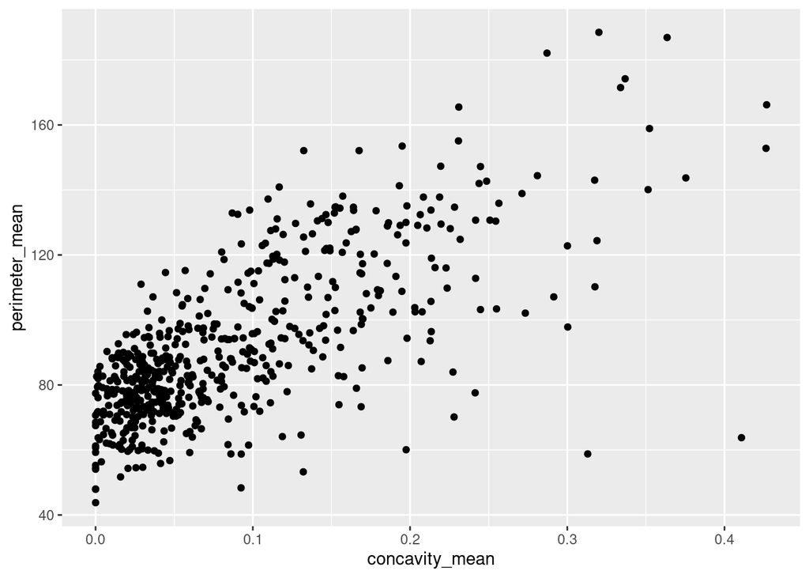

```r
cancer_plot <- ggplot(breastcancer, aes(x = concavity_mean, y = perimeter_mean)) + geom_point()

cancer_plot
```

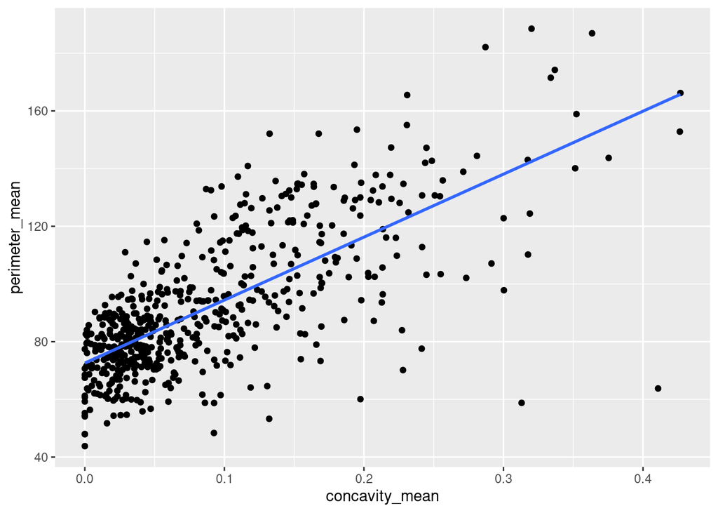

```r
cancer_plot + geom_smooth(method = "lm", se = FALSE)
```

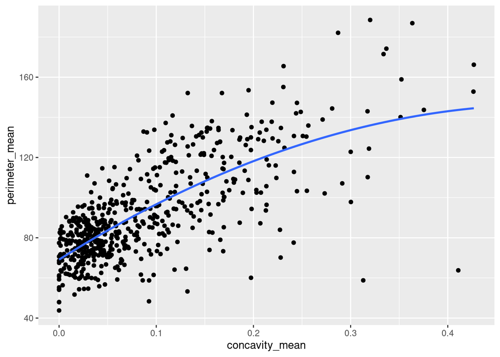

```r
# Model_2: 2 predictors (Y = b0 + b1 X + b2 X^2)
cancer_plot + geom_smooth(method = "lm", se = FALSE, formula = y ~ poly(x, 2))
```

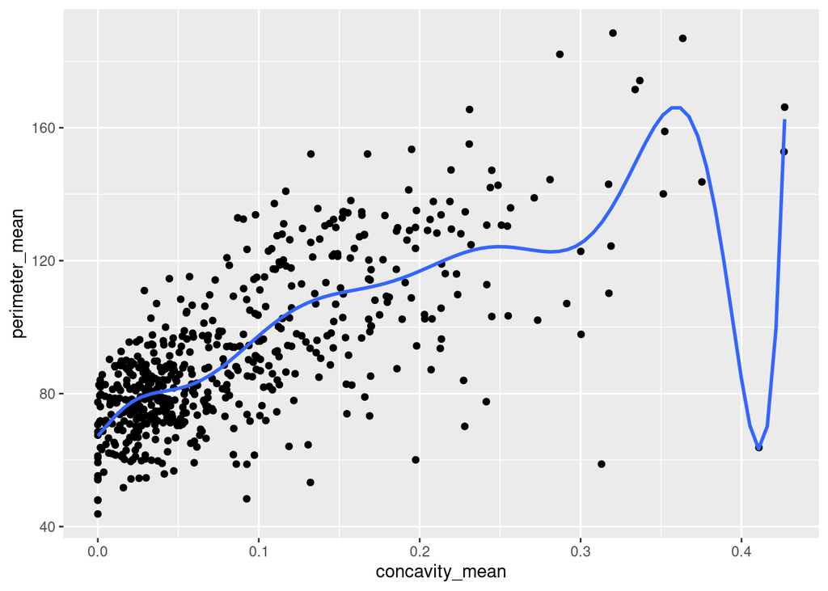

```r
# Model_3: 10 predictors (Y = b0 + b1 X + b2 X^2 + ... + b10 X^10)
cancer_plot + geom_smooth(method = "lm", se = FALSE, formula = y ~ poly(x, 10))
```

```r
# Set the random number seed
set.seed(8)

# Split the cars data into 80% / 20%
# Ensure that the sub-samples are similar with respect to mpg
cancer_split = initial_split(breastcancer, strata = perimeter_mean, prop = .8)
```

```r
# Get the training data from the split
cancer_train = training(cancer_split)

# Get the testing data from the split
cancer_test = testing(cancer_split)
```

```r
nrow(breastcancer)
```

```
[1] 569
```

```r
nrow(cancer_train)
```

```
[1] 453
```

```r
nrow(cancer_test)
```

```
[1] 116
```

```r
lm_spec <- linear_reg() %>% set_mode('regression') %>% set_engine('lm')
```

```r
# Step 2: Model estimation
cancer_model <- lm_spec %>%
  fit(perimeter_mean ~ concavity_mean, data = breastcancer)
```

```r
model_10_train <- lm_spec %>%
  fit(perimeter_mean ~ poly(concavity_mean, 10), data = breastcancer)
```

```r
# How well does the TRAINING model predict the TRAINING data?
# Calculate the training (in-sample) MAE
model_10_train %>%
  augment(new_data = cancer_train) %>%
  mae(truth = perimeter_mean, estimate = .pred)
```

```
# A tibble: 1 × 3
  .metric .estimator .estimate
  <chr>   <chr>          <dbl>
1 mae     standard        12.3
```

```r
# How well does the TRAINING model predict the TEST data?
# Calculate the test MAE
# YOUR CODE HERE
model_10_train %>%
  augment(new_data = cancer_test) %>%
  mae(truth = perimeter_mean, estimate = .pred)
```

```
# A tibble: 1 × 3
  .metric .estimator .estimate
  <chr>   <chr>          <dbl>
1 mae     standard        12.7
```

State which error metric you are using (MAE or MSE) and give its formal mathematical definition. Why did you choose this error metric? What are the advantages/disadvantages of using it?

Hint: MAEj (the mean absolute error for the jth fold, which has nj observations in it) is the 1 norm of the error vector e = y -y = (y1,…,ynj) - (y1,…, ynj) divided by the number of observations (nj). See your notes from Vector Norms (Blackboard Lecture). Hint: MSEj (mean square error for jth fold, which has nj observations) is the squared 2-norm of the error vector e = y -y = (y1,…,ynj) - (y1,…, ynj) divided by the number of observations (nj). See your notes from Vector Norms (Blackboard Lecture).

Implement k-fold cross validation for k = 10.

```r
set.seed(244)

cancer_model_cv = lm_spec %>%
fit_resamples(
  perimeter_mean ~ concavity_mean,
  resamples = vfold_cv(breastcancer, v = 10),
  metrics = metric_set(mae, rmse, rsq)
  )
```

```r
cancer_model_cv %>% collect_metrics()
```

```
# A tibble: 3 × 6
  .metric .estimator   mean     n std_err .config
  <chr>   <chr>       <dbl> <int>   <dbl> <chr>
1 mae     standard   12.8      10  0.519  Preprocessor1_Model1
2 rmse    standard   16.9      10  0.688  Preprocessor1_Model1
3 rsq     standard    0.530    10  0.0492 Preprocessor1_Model1
```

```r
cancer_model_cv %>% unnest(.metrics) %>%
filter(.metric == "mae")
```

```
# A tibble: 10 × 7
   splits           id     .metric .estimator .estimate .config         .notes
   <list>           <chr>  <chr>   <chr>          <dbl> <chr>           <list>
 1 <split [512/57]> Fold01 mae     standard        14.5 Preprocessor1_… <tibble>
 2 <split [512/57]> Fold02 mae     standard        14.2 Preprocessor1_… <tibble>
 3 <split [512/57]> Fold03 mae     standard        13.0 Preprocessor1_… <tibble>
 4 <split [512/57]> Fold04 mae     standard        11.4 Preprocessor1_… <tibble>
 5 <split [512/57]> Fold05 mae     standard        14.8 Preprocessor1_… <tibble>
 6 <split [512/57]> Fold06 mae     standard        10.7 Preprocessor1_… <tibble>
 7 <split [512/57]> Fold07 mae     standard        11.8 Preprocessor1_… <tibble>
 8 <split [512/57]> Fold08 mae     standard        13.8 Preprocessor1_… <tibble>
 9 <split [512/57]> Fold09 mae     standard        13.6 Preprocessor1_… <tibble>
10 <split [513/56]> Fold10 mae     standard        10.3 Preprocessor1_… <tibble>
```

Based on my random folds above, the prediction error (MAE) was best for fold 10 and worst for fold 5.

```r
# 10-fold cross-validation for model_1
set.seed(244)
model_1_cv <- lm_spec %>%
  fit_resamples(
    perimeter_mean ~ texture_mean + concavity_mean + smoothness_mean,
    resamples = vfold_cv(breastcancer, v = 10),
    metrics = metric_set(mae, rsq)
  )
```

```r
# 10-fold cross-validation for model_2
set.seed(253)
model_2_cv <- lm_spec %>%
  fit_resamples(
    perimeter_mean ~ texture_mean * concavity_mean + smoothness_mean,
    resamples = vfold_cv(breastcancer, v = 10),
    metrics = metric_set(mae, rsq)
  )
```

```r
model_1_cv %>%
  collect_metrics()
```

```
# A tibble: 2 × 6
  .metric .estimator   mean     n std_err .config
  <chr>   <chr>       <dbl> <int>   <dbl> <chr>
1 mae     standard   12.0      10  0.544  Preprocessor1_Model1
2 rsq     standard    0.568    10  0.0499 Preprocessor1_Model1
```

```r
model_2_cv %>%
  collect_metrics()
```

```
# A tibble: 2 × 6
  .metric .estimator   mean     n std_err .config
  <chr>   <chr>       <dbl> <int>   <dbl> <chr>
1 mae     standard   11.9      10  0.528  Preprocessor1_Model1
2 rsq     standard    0.560    10  0.0327 Preprocessor1_Model1
```

Display evaluation metrics for your different models in a clean, organized way. This display should include both the estimated CV metric as well as its standard deviation.

```r
# STEP 2: model estimation
model_1 <- lm_spec %>%
  fit(perimeter_mean ~ texture_mean + concavity_mean + smoothness_mean, data = breastcancer)

model_2 <- lm_spec %>%
  fit(perimeter_mean ~ texture_mean * concavity_mean + smoothness_mean, data = breastcancer)
```

```r
# IN-SAMPLE R^2 for model_1 = ???
model_1 %>% glance()
```

```
# A tibble: 1 × 12
  r.squared adj.r.squared sigma statistic  p.value    df logLik   AIC   BIC
      <dbl>         <dbl> <dbl>     <dbl>    <dbl> <dbl>  <dbl> <dbl> <dbl>
1     0.557         0.555  16.2      237. 1.96e-99     3 -2391. 4791. 4813.
# ℹ 3 more variables: deviance <dbl>, df.residual <int>, nobs <int>
```

```r
# IN-SAMPLE R^2 for model_2 = ???
model_2 %>% glance()
```

```
# A tibble: 1 × 12
  r.squared adj.r.squared sigma statistic   p.value    df logLik   AIC   BIC
      <dbl>         <dbl> <dbl>     <dbl>     <dbl> <dbl>  <dbl> <dbl> <dbl>
1     0.565         0.562  16.1      183. 2.36e-100     4 -2386. 4783. 4809.
# ℹ 3 more variables: deviance <dbl>, df.residual <int>, nobs <int>
```

```r
# IN-SAMPLE MAE for model_1 = ???
model_1 %>%
  augment(new_data = breastcancer) %>%
  mae(truth = perimeter_mean, estimate = .pred)
```

```
# A tibble: 1 × 3
  .metric .estimator .estimate
  <chr>   <chr>          <dbl>
1 mae     standard        11.9
```

```r
# IN-SAMPLE MAE for model_2 = ???
model_2 %>%
  augment(new_data = breastcancer) %>%
  mae(truth = perimeter_mean, estimate = .pred)
```

```
# A tibble: 1 × 3
  .metric .estimator .estimate
  <chr>   <chr>          <dbl>
1 mae     standard        11.9
```

Try different values of k (the tuning parameter). At minimum, try k = n - 1 (LOOCV), and k = 5. Which value of k has the smallest CV error?

```r
model_1_loocv <- lm_spec %>%
  fit_resamples(
    perimeter_mean ~ texture_mean + concavity_mean + smoothness_mean,
    resamples = vfold_cv(breastcancer, v = 40),
    metrics = metric_set(mae)
  )
```

```r
model_1_loocv %>% collect_metrics
```

```
# A tibble: 1 × 6
  .metric .estimator  mean     n std_err .config
  <chr>   <chr>      <dbl> <int>   <dbl> <chr>
1 mae     standard    12.0    40   0.503 Preprocessor1_Model1
```

```r
# 5-fold cross-validation for model_1
set.seed(244)

cancer_model_cv = lm_spec %>%
fit_resamples(
  perimeter_mean ~ concavity_mean,
  resamples = vfold_cv(breastcancer, v = 5),
  metrics = metric_set(mae, rmse, rsq)
  )
```

```r
cancer_model_cv %>% collect_metrics()
```

```
# A tibble: 3 × 6
  .metric .estimator   mean     n std_err .config
  <chr>   <chr>       <dbl> <int>   <dbl> <chr>
1 mae     standard   12.8       5  0.190  Preprocessor1_Model1
2 rmse    standard   17.1       5  0.269  Preprocessor1_Model1
3 rsq     standard    0.527     5  0.0334 Preprocessor1_Model1
```

```r
cancer_model_cv %>% unnest(.metrics) %>%
filter(.metric == "mae")
```

```
# A tibble: 5 × 7
  splits            id    .metric .estimator .estimate .config          .notes
  <list>            <chr> <chr>   <chr>          <dbl> <chr>            <list>
1 <split [455/114]> Fold1 mae     standard        12.7 Preprocessor1_M… <tibble>
2 <split [455/114]> Fold2 mae     standard        12.9 Preprocessor1_M… <tibble>
3 <split [455/114]> Fold3 mae     standard        13.5 Preprocessor1_M… <tibble>
4 <split [455/114]> Fold4 mae     standard        12.5 Preprocessor1_M… <tibble>
5 <split [456/113]> Fold5 mae     standard        12.6 Preprocessor1_M… <tibble>
```

Based on my random folds above, the prediction error (MAE) was best for fold 4 and worst for fold 3.

```r
# 5-fold cross-validation for model_1
set.seed(244)
model_1_cv <- lm_spec %>%
  fit_resamples(
    perimeter_mean ~ texture_mean + concavity_mean + smoothness_mean,
    resamples = vfold_cv(breastcancer, v = 5),
    metrics = metric_set(mae, rsq)
  )
```

```r
# 5-fold cross-validation for model_2
set.seed(253)
model_2_cv <- lm_spec %>%
  fit_resamples(
    perimeter_mean ~ texture_mean * concavity_mean + smoothness_mean,
    resamples = vfold_cv(breastcancer, v = 5),
    metrics = metric_set(mae, rsq)
  )
```

```r
model_1_cv %>%
  collect_metrics()
```

```
# A tibble: 2 × 6
  .metric .estimator   mean     n std_err .config
  <chr>   <chr>       <dbl> <int>   <dbl> <chr>
1 mae     standard   12.0       5  0.236  Preprocessor1_Model1
2 rsq     standard    0.569     5  0.0396 Preprocessor1_Model1
```

```r
model_2_cv %>%
  collect_metrics()
```

```
# A tibble: 2 × 6
  .metric .estimator   mean     n std_err .config
  <chr>   <chr>       <dbl> <int>   <dbl> <chr>
1 mae     standard   11.9       5  0.599  Preprocessor1_Model1
2 rsq     standard    0.556     5  0.0418 Preprocessor1_Model1
```

```r
# 8-fold cross-validation
set.seed(244)

cancer_model_cv = lm_spec %>%
fit_resamples(
  perimeter_mean ~ concavity_mean,
  resamples = vfold_cv(breastcancer, v = 8),
  metrics = metric_set(mae, rmse, rsq)
  )
```

```r
cancer_model_cv %>% collect_metrics()
```

```
# A tibble: 3 × 6
  .metric .estimator   mean     n std_err .config
  <chr>   <chr>       <dbl> <int>   <dbl> <chr>
1 mae     standard   12.8       8  0.399  Preprocessor1_Model1
2 rmse    standard   16.9       8  0.765  Preprocessor1_Model1
3 rsq     standard    0.517     8  0.0406 Preprocessor1_Model1
```

```r
cancer_model_cv %>% unnest(.metrics) %>%
filter(.metric == "mae")
```

```
# A tibble: 8 × 7
  splits           id    .metric .estimator .estimate .config           .notes
  <list>           <chr> <chr>   <chr>          <dbl> <chr>             <list>
1 <split [497/72]> Fold1 mae     standard        14.8 Preprocessor1_Mo… <tibble>
2 <split [498/71]> Fold2 mae     standard        11.2 Preprocessor1_Mo… <tibble>
3 <split [498/71]> Fold3 mae     standard        13.0 Preprocessor1_Mo… <tibble>
4 <split [498/71]> Fold4 mae     standard        12.2 Preprocessor1_Mo… <tibble>
5 <split [498/71]> Fold5 mae     standard        13.5 Preprocessor1_Mo… <tibble>
6 <split [498/71]> Fold6 mae     standard        11.8 Preprocessor1_Mo… <tibble>
7 <split [498/71]> Fold7 mae     standard        12.5 Preprocessor1_Mo… <tibble>
8 <split [498/71]> Fold8 mae     standard        13.2 Preprocessor1_Mo… <tibble>
```

Based on my random folds above, the prediction error (MAE) was best for fold 2 and worst for fold 1.

```r
# 8-fold cross-validation for model_1
set.seed(244)
model_1_cv <- lm_spec %>%
  fit_resamples(
    perimeter_mean ~ texture_mean + concavity_mean + smoothness_mean,
    resamples = vfold_cv(breastcancer, v = 8),
    metrics = metric_set(mae, rsq)
  )
```

```r
# 8-fold cross-validation for model_2
set.seed(244)
model_2_cv <- lm_spec %>%
  fit_resamples(
    perimeter_mean ~ texture_mean * concavity_mean + smoothness_mean,
    resamples = vfold_cv(breastcancer, v = 8),
    metrics = metric_set(mae, rsq)
  )
```

```r
model_1_cv %>%
  collect_metrics()
```

```
# A tibble: 2 × 6
  .metric .estimator   mean     n std_err .config
  <chr>   <chr>       <dbl> <int>   <dbl> <chr>
1 mae     standard   11.9       8  0.461  Preprocessor1_Model1
2 rsq     standard    0.557     8  0.0418 Preprocessor1_Model1
```

```r
model_2_cv %>%
  collect_metrics()
```

```
# A tibble: 2 × 6
  .metric .estimator   mean     n std_err .config
  <chr>   <chr>       <dbl> <int>   <dbl> <chr>
1 mae     standard   12.0       8  0.457  Preprocessor1_Model1
2 rsq     standard    0.553     8  0.0403 Preprocessor1_Model1
```

Select your final model based on which one has the smallest CV error.